# Kvasir data CNN model

### Import all the Dependencies for 3D images

```python
import tensorflow as tf
from tensorflow.keras import models, layers
import matplotlib.pyplot as plt
from IPython.display import HTML
from datetime import datetime
```

### Set all the Constants

```python
train_dir = ".../kvasir-dataset-v2"
```

```python
BATCH_SIZE = 32
IMAGE_SIZE = 256
CHANNELS=3
```

### Import data into tensorflow dataset object

```python
def Data_read(data_dir):
    return tf.keras.preprocessing.image_dataset_from_directory(
        data_dir,
        seed=123,
        shuffle=True,
        image_size=(IMAGE_SIZE,IMAGE_SIZE),
        batch_size=BATCH_SIZE)
```

```python
data = Data_read(train_dir)
```

```
Found 8000 files belonging to 8 classes.
```

```python
class_names = data.class_names
class_names
```

```
['dyed-lifted-polyps',
 'dyed-resection-margins',
 'esophagitis',
 'normal-cecum',
 'normal-pylorus',
 'normal-z-line',
 'polyps',
 'ulcerative-colitis']
```

```python
for image_batch, labels_batch in data.take(1):
    print(image_batch.shape)
    print(labels_batch.numpy())
```

```
(32, 256, 256, 3)
[6 7 6 0 2 4 4 1 7 4 5 5 6 7 2 7 4 4 1 2 4 2 4 2 7 5 4 7 1 6 2 3]
```

As you can see above, each element in the dataset is a tuple. First element is a batch of 32 elements of images. Second element is a batch of 32 elements of class labels

### Visualize some of the images from our dataset

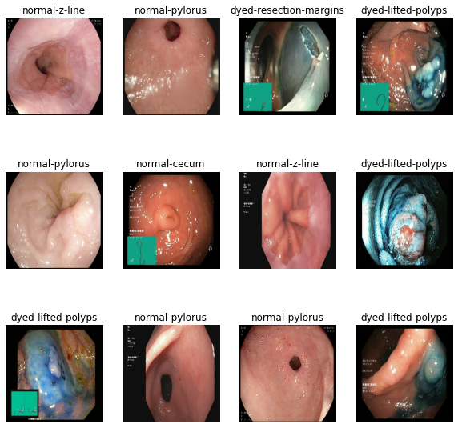

```python
plt.figure(figsize=(10, 10))
for image_batch, labels_batch in data.take(1):
    for i in range(12):
        ax = plt.subplot(3, 4, i + 1)
        plt.imshow(image_batch[i].numpy().astype("uint8"))
        plt.title(class_names[labels_batch[i]])
        plt.axis("off")
```

### Function to Split Dataset

Dataset should be bifurcated into 3 subsets, namely:

1. Training: Dataset to be used while training
2. Validation: Dataset to be tested against while training
3. Test: Dataset to be tested against after we trained a model

```python
def get_dataset_partitions_tf(ds, train_split=0.7, val_split=0.2, test_split=.1, shuffle=True, shuffle_size=10000):
    assert (train_split + test_split + val_split) == 1

    ds_size = len(ds)

    if shuffle:
        ds = ds.shuffle(shuffle_size, seed=12)

    train_size = int(train_split * ds_size)+1
    val_size = int(val_split * ds_size)

    train_ds = ds.take(train_size)
    val_ds = ds.skip(train_size).take(val_size)
    test_ds = ds.skip(train_size).skip(val_size)

    return train_ds, val_ds, test_ds
```

```python
train_ds, val_ds, test_ds = get_dataset_partitions_tf(data)
```

```python
len(train_ds)
```

```
176
```

```python
len(val_ds)
```

```
50
```

```python
len(test_ds)
```

```
24
```

## Building the Model

### Creating a Layer for Resizing and Normalization

You might be thinking why do we need to resize (256,256) image to again (256,256). You are right we don't need to but this will be useful when we are done with the training and start using the model for predictions. At that time somone can supply an image that is not (256,256) and this layer will resize it

```python
resize_and_rescale = tf.keras.Sequential([
  layers.experimental.preprocessing.Resizing(IMAGE_SIZE, IMAGE_SIZE),
  layers.experimental.preprocessing.Rescaling(1./255),
])
```

### Data Augmentation

Data Augmentation is needed when we have less data, this boosts the accuracy of our model by augmenting the data.

```python
data_augmentation = tf.keras.Sequential([
  layers.experimental.preprocessing.RandomFlip("horizontal_and_vertical"),
  layers.experimental.preprocessing.RandomRotation(0.2),
])
```

#### Applying Data Augmentation to Train Dataset

```python
train_ds = train_ds.map(
    lambda x, y: (data_augmentation(x, training=True), y)
).prefetch(buffer_size=tf.data.AUTOTUNE)
```

### Model Architecture

```python
input_shape = (BATCH_SIZE, IMAGE_SIZE, IMAGE_SIZE, CHANNELS)
n_classes = 8

model = models.Sequential([
    resize_and_rescale,
    layers.Conv2D(32, kernel_size = (3,3), activation='relu', input_shape=input_shape),
    layers.MaxPooling2D((2, 2)),
    layers.Conv2D(64,  kernel_size = (3,3), activation='relu'),
    layers.MaxPooling2D((2, 2)),
    layers.Conv2D(64,  kernel_size = (3,3), activation='relu'),
    layers.MaxPooling2D((2, 2)),
    layers.Conv2D(64, (3, 3), activation='relu'),
    layers.MaxPooling2D((2, 2)),
    layers.Conv2D(64, (3, 3), activation='relu'),
    layers.MaxPooling2D((2, 2)),
    layers.Conv2D(64, (3, 3), activation='relu'),
    layers.MaxPooling2D((2, 2)),
    layers.Flatten(),
    layers.Dense(64, activation='relu'),
    layers.Dense(n_classes, activation='softmax'),
])

model.build(input_shape=input_shape)
```

```python
model.summary()
```

```
Model: "sequential_2"
_________________________________________________________________
 Layer (type)                Output Shape              Param #
=================================================================
 sequential (Sequential)     (32, 256, 256, 3)         0

 conv2d (Conv2D)             (32, 254, 254, 32)        896

 max_pooling2d (MaxPooling2D  (32, 127, 127, 32)       0
 )

 conv2d_1 (Conv2D)           (32, 125, 125, 64)        18496

 max_pooling2d_1 (MaxPooling  (32, 62, 62, 64)         0
 2D)

 conv2d_2 (Conv2D)           (32, 60, 60, 64)          36928

 max_pooling2d_2 (MaxPooling  (32, 30, 30, 64)         0
 2D)

 conv2d_3 (Conv2D)           (32, 28, 28, 64)          36928

 max_pooling2d_3 (MaxPooling  (32, 14, 14, 64)         0
 2D)

 conv2d_4 (Conv2D)           (32, 12, 12, 64)          36928

 max_pooling2d_4 (MaxPooling  (32, 6, 6, 64)           0
 2D)

 conv2d_5 (Conv2D)           (32, 4, 4, 64)            36928

 max_pooling2d_5 (MaxPooling  (32, 2, 2, 64)           0
 2D)

 flatten (Flatten)           (32, 256)                 0

 dense (Dense)               (32, 64)                  16448

 dense_1 (Dense)             (32, 8)                   520

=================================================================
Total params: 184,072
Trainable params: 184,072
Non-trainable params: 0
_________________________________________________________________
```

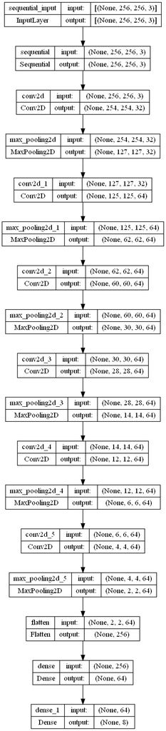

```python
from keras.utils.vis_utils import plot_model
plot_model(model, to_file='model_cnn_plot.png', show_shapes=True, show_layer_names=True)
```

```python
from keras.callbacks import ModelCheckpoint, EarlyStopping
from tensorflow.keras.callbacks import EarlyStopping, ReduceLROnPlateau, TensorBoard, ModelCheckpoint

callbacks = [
    EarlyStopping(monitor='val_loss', patience=3, verbose=1, min_delta=1e-4),
    ModelCheckpoint('model.h5', monitor='val_loss', verbose=1, save_best_only=True, mode='auto'),
]

tensorboard = TensorBoard(log_dir = 'logs')
reduce_lr = ReduceLROnPlateau(monitor = 'val_accuracy', factor = 0.3, patience = 2, min_delta = 0.001,
                              mode='auto',verbose=1)
```

### Compiling the Model

We use `adam` Optimizer, `SparseCategoricalCrossentropy` for losses, `accuracy` as a metric

```python
model.compile(
    optimizer= 'adam',
    loss= tf.keras.losses.SparseCategoricalCrossentropy(from_logits=False),
    metrics= ['accuracy']
)
```

```python
history = model.fit(
    train_ds,
    batch_size=BATCH_SIZE,
    validation_data=val_ds,
    verbose=1,
    epochs=20,
    callbacks = callbacks
)
```

```
Epoch 1: val_loss improved from inf to 0.90907, saving model to model.h5
Epoch 2: val_loss did not improve from 0.90907
Epoch 3: val_loss improved from 0.90907 to 0.74158, saving model to model.h5
Epoch 4: val_loss did not improve from 0.74158
Epoch 5: val_loss improved from 0.74158 to 0.69077, saving model to model.h5
Epoch 6: val_loss improved from 0.69077 to 0.66065, saving model to model.h5
Epoch 7: val_loss did not improve from 0.66065
Epoch 8: val_loss improved from 0.66065 to 0.62602, saving model to model.h5
Epoch 9: val_loss improved from 0.62602 to 0.59057, saving model to model.h5
Epoch 10: val_loss did not improve from 0.59057
Epoch 11: val_loss did not improve from 0.59057
Epoch 12: val_loss improved from 0.59057 to 0.58438, saving model to model.h5
Epoch 13: val_loss improved from 0.58438 to 0.57634, saving model to model.h5
Epoch 14: val_loss improved from 0.57634 to 0.55568, saving model to model.h5
Epoch 15: val_loss did not improve from 0.55568
Epoch 16: val_loss improved from 0.55568 to 0.55229, saving model to model.h5
Epoch 17: val_loss improved from 0.55229 to 0.53293, saving model to model.h5
Epoch 18: val_loss did not improve from 0.53293
Epoch 19: val_loss did not improve from 0.53293
Epoch 20: val_loss improved from 0.53293 to 0.48586, saving model to model.h5
```

```python
scores = model.evaluate(test_ds)
```

```python
scores
```

```
[0.5249195694923401, 0.7565104365348816]
```

Scores is just a list containing loss and accuracy value

### Plotting the Accuracy and Loss Curves

```python
history
```

```
<keras.callbacks.History at 0x2608eb73640>
```

```python
history.params
```

```
{'verbose': 1, 'epochs': 20, 'steps': 176}
```

```python
history.history.keys()
```

```
dict_keys(['loss', 'accuracy', 'val_loss', 'val_accuracy'])
```

**loss, accuracy, val loss etc are a python list containing values of loss, accuracy etc at the end of each epoch**

```python
type(history.history['loss'])
```

```
list
```

```python
len(history.history['loss'])
```

```
20
```

```python
history.history['loss']# show loss for first 5 epochs
```

```
[1.226343035697937,
 0.9181224703788757,
 0.8183843493461609,
 0.762625515460968,
 0.715182363986969,
 0.681642472743988,
 0.6748533844947815,
 0.6779019236564636,
 0.6562314629554749,
 0.6428987979888916,
 0.6308329701423645,
 0.6370283365249634,
 0.6101826429367065,
 0.6060358285903931,
 0.5940486192703247,
 0.5895933508872986,
 0.5777837038040161,
 0.5830274224281311,
 0.5475158095359802,
 0.5597601532936096]
```

```python
acc = history.history['accuracy']
val_acc = history.history['val_accuracy']

loss = history.history['loss']
val_loss = history.history['val_loss']
```

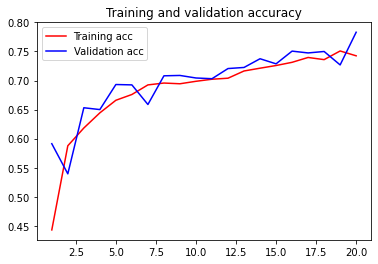

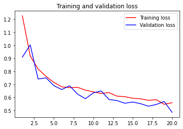

```python
epochs = range(1, len(acc) + 1)

plt.plot(epochs, acc, 'r', label='Training acc')
plt.plot(epochs, val_acc, 'b', label='Validation acc')
plt.title('Training and validation accuracy')
plt.legend()

plt.figure()

plt.plot(epochs, loss, 'r', label='Training loss')
plt.plot(epochs, val_loss, 'b', label='Validation loss')
plt.title('Training and validation loss')
plt.legend()

plt.show()
```

### Run prediction on a sample image

```
first image to predict
actual label: dyed-lifted-polyps
predicted label: dyed-lifted-polyps
```

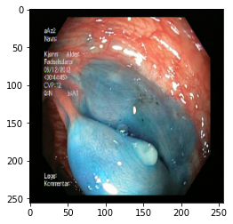

```python
import numpy as np
for images_batch, labels_batch in test_ds.take(1):

    first_image = images_batch[0].numpy().astype('uint8')
    first_label = labels_batch[0].numpy()

    print("first image to predict")
    plt.imshow(first_image)
    print("actual label:",class_names[first_label])

    batch_prediction = model.predict(images_batch)
    print("predicted label:",class_names[np.argmax(batch_prediction[0])])
```

### Write a function for inference

```python
def predict(model, img):
    img_array = tf.keras.preprocessing.image.img_to_array(images[i].numpy())
    img_array = tf.expand_dims(img_array, 0)

    predictions = model.predict(img_array)

    predicted_class = class_names[np.argmax(predictions[0])]
    confidence = round(100 * (np.max(predictions[0])), 2)
    return predicted_class, confidence
```

# Image Visualization and classification

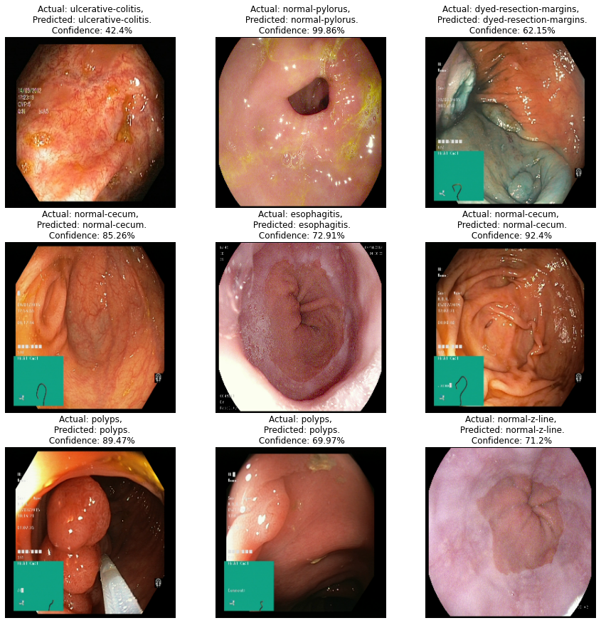

```python
plt.figure(figsize=(15, 15))
for images, labels in test_ds.take(1):
    for i in range(9):
        ax = plt.subplot(3, 3, i + 1)
        plt.imshow(images[i].numpy().astype("uint8"))

        predicted_class, confidence = predict(model, images[i].numpy())
        actual_class = class_names[labels[i]]

        plt.title(f"Actual: {actual_class},\n Predicted: {predicted_class}.\n Confidence: {confidence}%")

        plt.axis("off")
```

```python
predict(model, 16)
```

```
('normal-z-line', 71.2)
```